# MSSE 277B: Machine Learning

## Homework assignment #6: Clustering

### Assigned Mar3. and Due Mar. 14

### Student name: Charis Liao

# 1. KMeans.

We will now examine unsupervised learning for classification for the data set of chemical compounds. In the compounds .csv, 150 organic compounds which belong to 3 different types (phenol, ether and amide) were tested upon with 4 different testing reagents (denoted reagents A-D). We would like to cluster data points by unsupervised learning, where we would not use the true label to guide classification such as using a cost function, instead we directly learn from the given features themselves.

```python
# import modules
import numpy as np
import pandas as pd
import seaborn as sns
import matplotlib.pyplot as plt
```

```python
# Load csv file
compounds = pd.read_csv('compounds.csv')
compounds
```

|  | A | B | C | D | type |
| --- | --- | --- | --- | --- | --- |
| 0 | 6.4 | 2.9 | 4.3 | 1.3 | amide |
| 1 | 5.7 | 4.4 | 1.5 | 0.4 | phenol |
| 2 | 6.7 | 3.0 | 5.2 | 2.3 | ether |
| 3 | 5.8 | 2.8 | 5.1 | 2.4 | ether |
| 4 | 6.4 | 3.2 | 5.3 | 2.3 | ether |
| ... | ... | ... | ... | ... | ... |
| 145 | 5.4 | 3.9 | 1.3 | 0.4 | phenol |
| 146 | 6.3 | 2.5 | 5.0 | 1.9 | ether |
| 147 | 6.0 | 3.4 | 4.5 | 1.6 | amide |
| 148 | 6.2 | 2.9 | 4.3 | 1.3 | amide |
| 149 | 5.6 | 3.0 | 4.1 | 1.3 | amide |

150 rows × 5 columns

**(a) Rescale the features to a value between 0 and 1 by dividing the max of that feature. Visualize the data and comment on which features are correlated (utilize 2-3 seaborn methods as demonstrated in Tutorial 6).**

```python
# dropping unnecessary column
features = compounds.drop(['type'], axis = 1)
# rescale the features to value between 0 and 1
scaled_features = features / features.max()
scaled_features['type'] = compounds['type']
scaled_features
```

|  | A | B | C | D | type |
| --- | --- | --- | --- | --- | --- |
| 0 | 0.810127 | 0.659091 | 0.623188 | 0.52 | amide |
| 1 | 0.721519 | 1.000000 | 0.217391 | 0.16 | phenol |
| 2 | 0.848101 | 0.681818 | 0.753623 | 0.92 | ether |
| 3 | 0.734177 | 0.636364 | 0.739130 | 0.96 | ether |
| 4 | 0.810127 | 0.727273 | 0.768116 | 0.92 | ether |
| ... | ... | ... | ... | ... | ... |
| 145 | 0.683544 | 0.886364 | 0.188406 | 0.16 | phenol |
| 146 | 0.797468 | 0.568182 | 0.724638 | 0.76 | ether |
| 147 | 0.759494 | 0.772727 | 0.652174 | 0.64 | amide |
| 148 | 0.784810 | 0.659091 | 0.623188 | 0.52 | amide |
| 149 | 0.708861 | 0.681818 | 0.594203 | 0.52 | amide |

150 rows × 5 columns

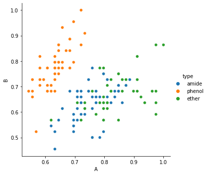

```python
ax1 = sns.relplot(data=scaled_features, x="A", y="B",hue=scaled_features['type'])
```

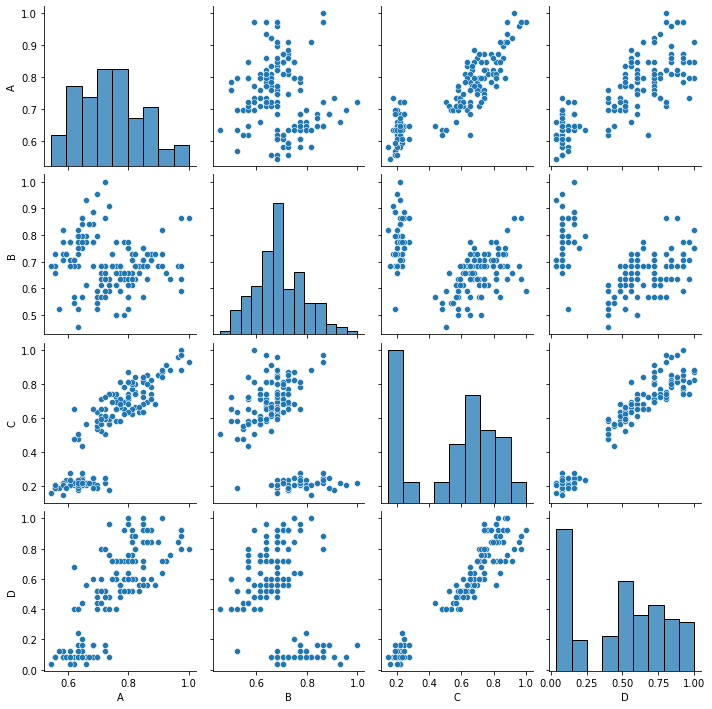

```python
# Pairplot to visualize the pairwise relationship between all features
sns.pairplot(scaled_features)
```

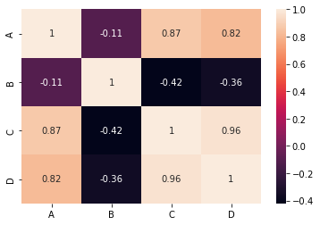

```python
# Heatmap to visualize the correlation between all features
sns.heatmap(scaled_features.corr(), annot=True)
```

From the multiple plots above, we can see that [A, C], [A, D], [C, D] are positively correlated while B's relationship with other features are negatively correlated.

**(b) Do KMeans clustering with K=2,3 and 4 clusters. Visualize your result (you can select 2 features to do visualization) and comment on which K value make the most sense to you according to the visualization you see. (Use the provided code if you are a ugrad or fill in the code for KMeans if you are a grad.)**

```python
import warnings

class KMeans():
    def __init__(self, K, maximum_iters=100):
        # K: number of clusters to be created
        # distance matrix is Eucledian distance
        self.K = K
        self.maximum_iters = maximum_iters

    def cluster(self, input_points):
        """ Do KMeans clustering
        input_points: np.array shape(ndata,nfeatures).
            Each feature is assumed to be normalized within range of [0,1]
        """
        centroids = np.random.random((self.K, input_points.shape[1]))
        assignments = np.zeros_like(input_points.shape[0])
        new_assignments = self.create_new_assignments(centroids, input_points)

        # restart if run into bad initialization
        # Comment out this part for Q1.(d)
        if len(np.unique(new_assignments))<self.K:
            return self.cluster(input_points)

        n_iters = 1
        while (new_assignments != assignments).any() and n_iters < self.maximum_iters:
            ### Compute the centroid given new assignment ###
            centroids = np.array([np.mean(input_points[new_assignments==i], axis=0) for i in range(self.K)])
            assignments = new_assignments

            ### Update the assignment with current centroids ###
            new_assignments = self.create_new_assignments(centroids, input_points)
            if len(np.unique(new_assignments))< self.K:
                warnings.warn('At least one centroid vanishes')
            n_iters += 1
            if n_iters == self.maximum_iters:
                print("Warning: Maximum number of iterations reached!")

        return new_assignments


    def create_new_assignments(self, centroids, data_points):
        """ Assign each datapoint to its nearest centroid.
        centroid: 2d array of the current centroid for each cluster
        data_points: 2d arrays recording the features of each data point.
        """
        ###Compute the distances that stores the Eucledian distances between each datapoints and the centroid ###
        #shape (ndata,ncentroid)
        distances = np.array([np.linalg.norm(data_points - centroid, axis=1) for centroid in centroids]).T
#         print(distances.shape)
        new_assignments = np.argmin(distances, axis=-1)
        return new_assignments
```

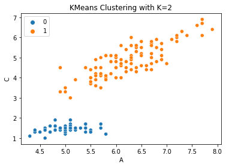

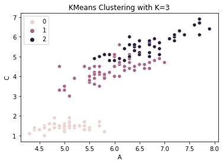

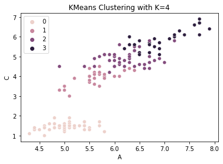

```python
compound_features = scaled_features.drop(['type'], axis = 1)

# print(compound_features.shape)

# Create an instance of the KMeans class with K=2, 3, 4
kmeans2 = KMeans(2)
kmeans3 = KMeans(3)
kmeans4 = KMeans(4)

# Perform KMeans clustering with each K value
clusters2 = kmeans2.cluster(compound_features.values)
clusters3 = kmeans3.cluster(compound_features.values)
clusters4 = kmeans4.cluster(compound_features.values)

# plot data with different cluster assignments
sns.scatterplot(x='A', y='C', hue=clusters2, data=compounds)
plt.title('KMeans Clustering with K=2')
plt.show()

sns.scatterplot(x='A', y='C', hue=clusters3, data=compounds)
plt.title('KMeans Clustering with K=3')
plt.show()

sns.scatterplot(x='A', y='C', hue=clusters4, data=compounds)
plt.title('KMeans Clustering with K=4')
plt.show()
```

From the scatterplots above, we can see the with K=2 clusters, the data is split into two groups. When K=3 clusters, data is split into three groups. when K=4 clusters, data is split into four groups. Based on the observations, I think K=3 clusters makes the most sense because the clusters are clear and easy to identify but not too simple with just only two clusters.

**(c) For K=3 clustering result, compare it to the true data label. How good is the classification?**

```python
def validate(y_hat,y):
    """print accuracy of prediction for each class for the compounds dataset
    yhat: np.array shape(ndata). Your prediction of classes
    y: np.array of str shape(ndata). data labels / groudn truths.
    """
    # correct classification
    compounds = np.unique(y) # should be ['amide','phenol','ether'] for compounds dataset
    clusters =[np.where((y==c)) for c in compounds]
    pred_class = np.unique(y_hat)

    #remove -1 for noise point in DBSCAN
    pred_class= np.delete(pred_class,np.where(pred_class==-1))
    assert len(pred_class) == len(compounds), f'y_hat has less or more than {len(compounds)} classes:{pred_class}'

    for i in range(3):
        #loop over solutions
        counts=[]
        scores=[]
        for j in range(3):
            #loop over clusters of true assignments
            sol_i= np.where((y_hat==pred_class[i]))
            counts.append(len(np.intersect1d(sol_i, clusters[j])))
            scores.append(counts[-1]/len(clusters[j]))
        idx = np.argmax(scores)
        print(f'Class {pred_class[i]} - {compounds[idx]}: {counts[idx]} out \
of {np.count_nonzero(clusters[idx])} are classified correctly')
    return
```

```python
validate(clusters3, compounds['type'])
```

```
Class 0 - phenol: 50 out of 50 are classified correctly
Class 1 - amide: 48 out of 49 are classified correctly
Class 2 - ether: 46 out of 50 are classified correctly
```

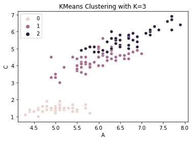

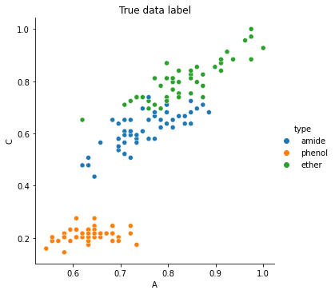

```python
sns.scatterplot(x='A', y='C', hue=clusters3, data=compounds)
plt.title('KMeans Clustering with K=3')
plt.show()

sns.relplot(data=scaled_features, x="A", y="C",hue=scaled_features['type'])
plt.title('True data label')
plt.show()
```

**(d) Comment out the part of the code that reinitialize the centroid if the initial assignment is not good. Run the KMeans algorithm multiple times with K=4, what problem do you see? Comment on how the choice of initial centroids might affect the results and what are the possible solutions.**

```python
import warnings

class KMeans_d():
    def __init__(self, K, maximum_iters=100):
        # K: number of clusters to be created
        # distance matrix is Eucledian distance
        self.K = K
        self.maximum_iters = maximum_iters

    def cluster(self, input_points):
        """ Do KMeans clustering
        input_points: np.array shape(ndata,nfeatures).
            Each feature is assumed to be normalized within range of [0,1]
        """
        centroids = np.random.random((self.K, input_points.shape[1]))
        assignments = np.zeros_like(input_points.shape[0])
        new_assignments = self.create_new_assignments(centroids, input_points)

        # restart if run into bad initialization
        # Comment out this part for Q1.(d)
#         if len(np.unique(new_assignments))<self.K:
#             return self.cluster(input_points)

        n_iters = 1
        while (new_assignments != assignments).any() and n_iters < self.maximum_iters:
            ### Compute the centroid given new assignment ###
            centroids = np.array([np.mean(input_points[new_assignments==i], axis=0) for i in range(self.K)])
            assignments = new_assignments

            ### Update the assignment with current centroids ###
            new_assignments = self.create_new_assignments(centroids, input_points)
            if len(np.unique(new_assignments))< self.K:
                warnings.warn('At least one centroid vanishes')
            n_iters += 1
            if n_iters == self.maximum_iters:
                print("Warning: Maximum number of iterations reached!")

        return new_assignments


    def create_new_assignments(self, centroids, data_points):
        """ Assign each datapoint to its nearest centroid.
        centroid: 2d array of the current centroid for each cluster
        data_points: 2d arrays recording the features of each data point.
        """
        ###Compute the distances that stores the Eucledian distances between each datapoints and the centroid ###
        #shape (ndata,ncentroid)
        distances = np.array([np.linalg.norm(data_points - centroid, axis=1) for centroid in centroids]).T
#         print(distances.shape)
        new_assignments = np.argmin(distances, axis=-1)
        return new_assignments
```

```python
# Run KMeans algorithm 10 times
n_runs = 10
results = []
for i in range(n_runs):
    kmeans = KMeans_d(K=4, maximum_iters=100)
    y_pred = kmeans.cluster(compound_features.values)
    results.append(y_pred)

# for i in range(len(results)):
#     print(f'{i} time')
#     validate(results[i], compounds['type'])
```

```
Warning: Maximum number of iterations reached!
Warning: Maximum number of iterations reached!
Warning: Maximum number of iterations reached!
Warning: Maximum number of iterations reached!
Warning: Maximum number of iterations reached!
Warning: Maximum number of iterations reached!
Warning: Maximum number of iterations reached!
Warning: Maximum number of iterations reached!
```

```
<ipython-input-56-0b2cca44ed74>:33: UserWarning: At least one centroid vanishes
  warnings.warn('At least one centroid vanishes')
```

There's a warning saying "At lease one centroid vanishes". This may occur when one or more cluster centroids collapse or converge to the same point, reslting in a "vanishing" centroid. The choice of initial centroids might affect the results because if the initial centroids are too close to each other, the algorithm may converge to a local minimum.

# 2 DBSCAN

**(a) ) Use DBSCAN to classify compounds dataset. Adjust the Rcut and MinPts hyperparameters so that we have 3 clusters. How many core, border and noise points do you have respectively? Compared to KMeans, is DBSCAN more effective?**

```python
from sklearn.cluster import DBSCAN

db = DBSCAN(eps=0.05, min_samples=4)
clustering = db.fit(compound_features.values)
# Cluster labels for each point in the dataset given to fit().  Noisy samples are given the label -1.
labels = clustering.labels_
# Indices of core samples.
core_samples = clustering.core_sample_indices_

validate(labels, compounds['type'])

# print(labels)
# print(core_samples)

# Print the number of core, border, and noise points in each cluster
n_clusters = len(set(labels)) - (1 if -1 in labels else 0)
print(f"Number of clusters: {n_clusters}")
for i in range(n_clusters):
    cluster_indices = np.where(labels == i)[0]
    n_core_samples = len(set(core_samples).intersection(set(cluster_indices)))
    n_border_samples = len(cluster_indices) - n_core_samples
    n_noise_samples = len(np.where(labels == -1)[0])
    print(f"Cluster {i}: {n_core_samples} core samples, {n_border_samples} border samples, {n_noise_samples} noise samples")
```

```
Class 0 - phenol: 33 out of 50 are classified correctly
Class 1 - ether: 4 out of 50 are classified correctly
Class 2 - amide: 6 out of 49 are classified correctly
Number of clusters: 3
Cluster 0: 25 core samples, 8 border samples, 106 noise samples
Cluster 1: 2 core samples, 3 border samples, 106 noise samples
Cluster 2: 3 core samples, 3 border samples, 106 noise samples
```

I think KMeans is more effective than DBSCAN.

**(b) Let’s work on the noisy moon dataset (provided in the reference code) instead. Try using DBSCAN and one of KMeans with K=2. Visualize the clustering result. This time which method works better?**

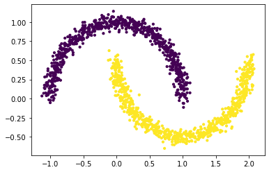

```
Number of clusters: 2
Cluster 0: 709 core samples, 29 border samples, 23 noise samples
Cluster 1: 705 core samples, 34 border samples, 23 noise samples
```

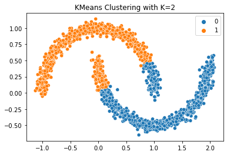

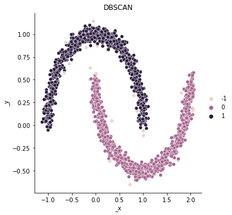

```python
from sklearn import cluster, datasets, mixture
from sklearn.preprocessing import StandardScaler
from itertools import cycle, islice
from pylab import *

np.random.seed(0)

# ============
# Generate datasets. We choose the size big enough to see the scalability
# of the algorithms, but not too big to avoid too long running times
# ============
n_samples = 1500
noisy_circles = datasets.make_circles(n_samples=n_samples, factor=0.5, noise=0.05)
noisy_moons = datasets.make_moons(n_samples=n_samples, noise=0.05)
# print(noisy_moons)
X,y=noisy_moons
plt.scatter(X[:, 0], X[:, 1], s=10,c=y)
plt.show()


# Standardize the data
scaler = StandardScaler()
X_std = scaler.fit_transform(X)


# Perform DBSCAN clustering
dbscan = DBSCAN(eps=0.1, min_samples=6)
y_dbscan = dbscan.fit(X_std)

# Cluster labels for each point in the dataset given to fit().  Noisy samples are given the label -1.
labels = y_dbscan.labels_
# Indices of core samples.
core_samples = y_dbscan.core_sample_indices_


# print(labels)
# print(core_samples)

# Print the number of core, border, and noise points in each cluster
n_clusters = len(set(labels)) - (1 if -1 in labels else 0)
print(f"Number of clusters: {n_clusters}")
for i in range(n_clusters):
    cluster_indices = np.where(labels == i)[0]
    n_core_samples = len(set(core_samples).intersection(set(cluster_indices)))
    n_border_samples = len(cluster_indices) - n_core_samples
    n_noise_samples = len(np.where(labels == -1)[0])
    print(f"Cluster {i}: {n_core_samples} core samples, {n_border_samples} border samples, {n_noise_samples} noise samples")

# Perform KMeans clustering
kmeans = KMeans(2)
y_kmeans = kmeans2.cluster(X_std)

sns.scatterplot(X[:, 0], X[:, 1], hue=y_kmeans)
plt.title('KMeans Clustering with K=2')
plt.show()

sns.relplot(X[:, 0], X[:, 1],hue=y_dbscan.labels_)
plt.title('DBSCAN')
plt.show()
```

This time DBSCAN works better because the clusering is more similiar to the original graph.

# You've reached the end of hw 6

[figure not shown]